# Newsroom Data Literacy

11/29/2021

## Introduction

- A quick roundup of important pieces of information to understand and use data as part of normal reporting
- You don’t need to be an expert to use data!
- Keep an eye out for common pitfalls
- Some parts of this might be basic to some of you, but hopefully everyone will find at least some of this helpful

## Three tiers of journalistic data literacy

- **BASIC:** You can parse a spreadsheet, request data, and avoid simple pitfalls
- **INTERMEDIATE:** You’re comfortable with spreadsheets, working with formulas and pivot tables, and making simple charts to visualize data
- **ADVANCED:** You’re familiar with one or more tools for working with big databases, code, geographic data, and how to request this data

My opinion: Not everyone needs to be a data expert. But in a mid-sized newsroom like MPR, every journalist should have at least Basic levels of data literacy, a majority should be Intermediate, and a few should be Advanced.

## Terms to know

- **CSV:** “Comma separated value,” a basic file format for spreadsheets, where each line is a row, & columns are separated by commas
  - Similar to Excel files (.XLS, .XLSX)
  - Open source and universal
  - Doesn’t store formatting
  - One sheet per document

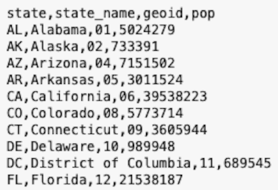

## Terms to know

- **GIS:** Geographic Information System, the discipline of using computers to analyze geographic data and make maps
- **ArcGIS/QGIS:** Two popular GIS programs. ArcGIS is the major commercial GIS program, while QGIS is the free open-source variant
- **Shapefile:** A common file format for GIS data. Actually not one file but a collection of files with the same filename and different extensions — the `map.shp` file has the geographic data, the `map.dbf` file has accompanying data, and so on

## Terms to know

- **R:** A programming language optimized for statistics and data visualization
- **Python:** A general-purpose programming language with strong support for data
- **JavaScript:** A programming language focused on scripting web sites
- **D3:** A JavaScript library focused on interactive visualizations
- **SQL:** “Structured Query Language,” a programming language used for interacting with databases

## Terms to know

- **Pivot table:** A function in Excel and other spreadsheet programs to summarize a larger spreadsheet

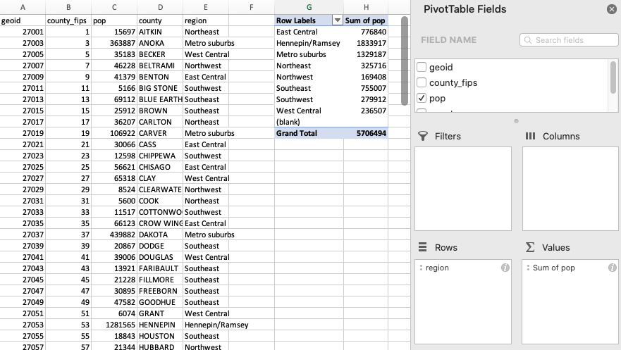

## Terms to know

- Summary data/raw data

### **Raw data**

```
## # A tibble: 8 × 3
##   carat cut       price
##   <dbl> <ord>     <chr>
## 1  0.23 Ideal     $326
## 2  0.21 Premium   $326
## 3  0.23 Good      $327
## 4  0.29 Premium   $334
## 5  0.31 Good      $335
## 6  0.24 Very Good $336
## 7  0.24 Very Good $336
## 8  0.26 Very Good $337
```

One row per subject/incident

### **Summary data**

```
## # A tibble: 5 × 3
##   cut       diamonds average_price
##   <ord>     <chr>    <chr>
## 1 Fair      1,610    $4,359
## 2 Good      4,906    $3,929
## 3 Very Good 12,082   $3,982
## 4 Premium   13,791   $4,584
## 5 Ideal     21,551   $3,458
```

One row per category

## Basics of analyzing data

- Edit in a copy, not the original
- Record your steps, maybe save as new files periodically
- Never encode information in color or formatting

## Basics of analyzing data

- “Wide” vs. “Tall”/“Long” data

| artist | track | date.entered | wk1 | wk2 | wk3 | wk4 | wk5 | wk6 | wk7 | wk8 | wk9 | wk10 | wk11 | wk12 | wk13 | wk14 | wk15 | wk16 | wk17 | wk18 | wk19 | wk20 | wk21 | wk22 | wk23 | wk24 | wk25 | wk26 | wk27 | … |
| --- | --- | --- | --- | --- | --- | --- | --- | --- | --- | --- | --- | --- | --- | --- | --- | --- | --- | --- | --- | --- | --- | --- | --- | --- | --- | --- | --- | --- | --- | --- |
| 2 Pac | Baby Don’t Cry (Keep… | 2000-02-26 | 87 | 82 | 72 | 77 | 87 | 94 | 99 | NA | NA | NA | NA | NA | NA | NA | NA | NA | NA | NA | NA | NA | NA | NA | NA | NA | NA | NA | NA | … |
| 2Ge+her | The Hardest Part Of … | 2000-09-02 | 91 | 87 | 92 | NA | NA | NA | NA | NA | NA | NA | NA | NA | NA | NA | NA | NA | NA | NA | NA | NA | NA | NA | NA | NA | NA | NA | NA | … |
| 3 Doors Down | Kryptonite | 2000-04-08 | 81 | 70 | 68 | 67 | 66 | 57 | 54 | 53 | 51 | 51 | 51 | 51 | 47 | 44 | 38 | 28 | 22 | 18 | 18 | 14 | 12 | 7 | 6 | 6 | 6 | 5 | 5 | … |
| 3 Doors Down | Loser | 2000-10-21 | 76 | 76 | 72 | 69 | 67 | 65 | 55 | 59 | 62 | 61 | 61 | 59 | 61 | 66 | 72 | 76 | 75 | 67 | 73 | 70 | NA | NA | NA | NA | NA | NA | NA | … |
| 504 Boyz | Wobble Wobble | 2000-04-15 | 57 | 34 | 25 | 17 | 17 | 31 | 36 | 49 | 53 | 57 | 64 | 70 | 75 | 76 | 78 | 85 | 92 | 96 | NA | NA | NA | NA | NA | NA | NA | NA | NA | … |
| 98^0 | Give Me Just One Nig… | 2000-08-19 | 51 | 39 | 34 | 26 | 26 | 19 | 2 | 2 | 3 | 6 | 7 | 22 | 29 | 36 | 47 | 67 | 66 | 84 | 93 | 94 | NA | NA | NA | NA | NA | NA | NA | … |
| A*Teens | Dancing Queen | 2000-07-08 | 97 | 97 | 96 | 95 | 100 | NA | NA | NA | NA | NA | NA | NA | NA | NA | NA | NA | NA | NA | NA | NA | NA | NA | NA | NA | NA | NA | NA | … |
| Aaliyah | I Don’t Wanna | 2000-01-29 | 84 | 62 | 51 | 41 | 38 | 35 | 35 | 38 | 38 | 36 | 37 | 37 | 38 | 49 | 61 | 63 | 62 | 67 | 83 | 86 | NA | NA | NA | NA | NA | NA | NA | … |
| Aaliyah | Try Again | 2000-03-18 | 59 | 53 | 38 | 28 | 21 | 18 | 16 | 14 | 12 | 10 | 9 | 8 | 6 | 1 | 2 | 2 | 2 | 2 | 3 | 4 | 5 | 5 | 6 | 9 | 13 | 14 | 16 | … |
| Adams, Yolanda | Open My Heart | 2000-08-26 | 76 | 76 | 74 | 69 | 68 | 67 | 61 | 58 | 57 | 59 | 66 | 68 | 61 | 67 | 59 | 63 | 67 | 71 | 79 | 89 | NA | NA | NA | NA | NA | NA | NA | … |

## Basics of analyzing data

- “Wide” vs. “Tall”/“Long” data

| artist | track | date.entered | week | rank |
| --- | --- | --- | --- | --- |
| 2 Pac | Baby Don’t Cry (Keep… | 2000-02-26 | 1 | 87 |
| 2 Pac | Baby Don’t Cry (Keep… | 2000-02-26 | 2 | 82 |
| 2 Pac | Baby Don’t Cry (Keep… | 2000-02-26 | 3 | 72 |
| 2 Pac | Baby Don’t Cry (Keep… | 2000-02-26 | 4 | 77 |
| 2 Pac | Baby Don’t Cry (Keep… | 2000-02-26 | 5 | 87 |
| 2 Pac | Baby Don’t Cry (Keep… | 2000-02-26 | 6 | 94 |
| 2 Pac | Baby Don’t Cry (Keep… | 2000-02-26 | 7 | 99 |
| 2Ge+her | The Hardest Part Of … | 2000-09-02 | 1 | 91 |
| 2Ge+her | The Hardest Part Of … | 2000-09-02 | 2 | 87 |
| 2Ge+her | The Hardest Part Of … | 2000-09-02 | 3 | 92 |

## Basics of analyzing data

- “Wide” vs. “Tall”/“Long” data
  - “Wide” data is often more easily read by humans; “Long” data is easier for machines to parse
  - “Long” data can lead to tidier column names
  - Sometimes one or the other will be easier to graph with whatever program you’re using
  - It’s not *that* hard to switch data between them, so don’t stress too much about this

## Which data tool to use?

- Calculator to compare a few numbers.
- Spreadsheet (Excel, Google Sheets, LibreOffice) to compare hundreds or thousands.
- Database or code (SQL, Access, R, Python) for hundreds of thousands of numbers

## Pitfalls to watch for

- Missing data
- Duplicated data
- Spelling differences (“Saint Louis” vs. “St. Louis”)
- Date formats (“12/25/2021” vs. “2021-12-25”)
- Sequences like `999999`
- Default dates like Jan. 1, 1970, or Jan. 1, 1900

## Pitfalls to watch for

- Confounding variables
- Weekly or seasonal patterns
- Inflation
- Definition/boundary changes

## Pitfalls to watch for

- Excel row limits (1,048,576 rows, or 65,536)

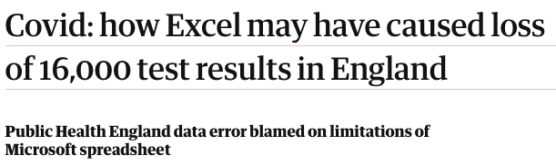

## Pitfalls to watch for

- Excel converting things to dates

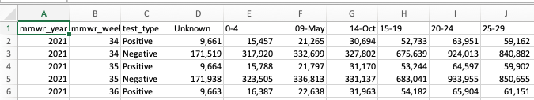

[figure not shown]

## Basics of vizualizing data

- Keep it simple
  - Avoid pointless embellishments like 3D bars or dozens of colors
- Charts should tell a story
- Recognize when words or tables would be better

## Basics of vizualizing data

## What type of chart to use

- Are you comparing the relationship between two different values for each point of data? **Scatterplot**
- Are you comparing values from several different categories? **Bar chart**
- Are you showing a change in one metric over time? A **line chart** if your data is relatively smooth or continuous, perhaps a **bar chart** if not
- Is geography important for your data? If so, make a map. If it’s not important, stick with a chart.

## What type of chart not to use

- No pie charts!
  - People are bad at judging which wedge of a pie chart is larger, if sizes are at all close
  - Instead, use a **bar chart**. It’s easier to compare relative values
- No dual-axis charts!
  - Your choice of scales can drastically change the apparent relationship between your two pieces of data
  - Instead, convert the metrics you want to compare into *percent change* from a fixed starting date

## What about truncated y-axes?

- You *can* truncate your y-axis — in the right situation
- **Bar charts** must always have y-axes that start at 0; if one bar is twice as tall as another, our minds assume the *value* of Bar A is twice as big as Bar B’s value, and truncated y-axes break that
- For other kinds of charts, it’s generally OK to cut out wasted space — no one expects a summer weather chart to go down to 0º, for example
- Be conscious of the story your choice of axis limits tells. Are you highlighting change or continuity? Is this fair?

## Logarithmic scales

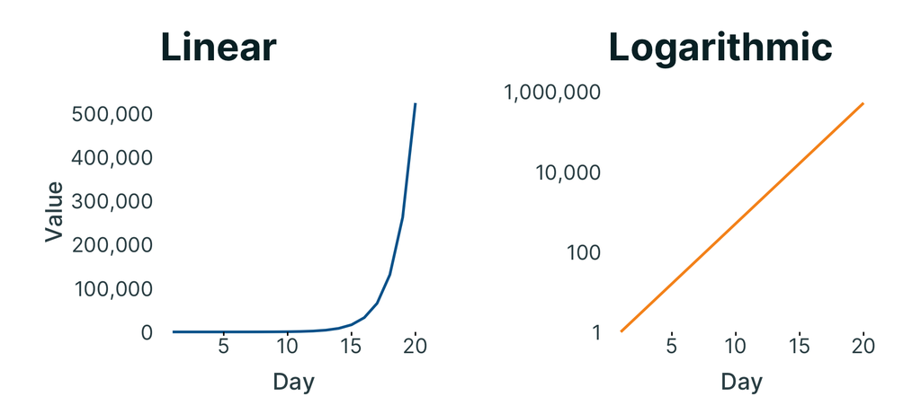

## What is a logarithmic scale?

- In a *linear* scale, you *add* a regular increment: 10, 20, 30, 40
- In a *logarithmic* scale, you *multiply* a regular increment: 10, 100, 1,000, 10,000

## Graphing logarithmic scales

### When to use a log scale

- When your growth is exponential (watch for J swoops!)
- When you want to plot really small numbers and really large numbers next to each other
- When the point is NOT to highlight outliers

### Important log scales:

- log2 is a sequence of doubling: 2, 4, 8, 16, 32, 64, 128, 256, 512, 1024, 2048
- log10 is a sequence increasing by 10: 10, 100, 1,000

### Always explain!

## Which scale to use?

[figure not shown]

## How to ask for data

- PDFs are not data!
- Ask for data in “machine-readable” format such as CSV, Excel, or a database
- Ask for the name of their database software
- Ask for the “record layout” — the names of the rows and columns in the database, minus the actual data
- Ask to talk to their IT person, who might actually know what’s going on
- If they won’t give raw data, ask for summary data
- Suggest they’d save themselves a lot of effort by just automatically publishing the data online

## Sources for free data

- U.S. Census
- [Census Reporter](https://censusreporter.org)
- [NHGIS](https://nhgis.org)
- [Our World In Data](https://ourworldindata.org)
- [Natural Earth](https://www.naturalearthdata.com)
- Wikipedia (as a starting point!)

Always check the data!

## Programs to consider:

- Spreadsheets:
  - Excel: Industry standard
  - Google Sheets: Free online version
  - LibreOffice: Open-source alternative
  - Numbers: Default on Macs; avoid
- GIS: [QGIS](https://qgis.org/en/site/) is free and open-source
- Extracting data from PDFs: [Tabula](https://tabula.technology)
- Programming: **R** is the primary language I use. You’ll need to [download R](https://cloud.r-project.org), and you’ll want to download the app [RStudio](https://www.rstudio.com/products/rstudio/) to provide a more user-friendly interface
- A plaintext editor like [Sublime Text](https://www.sublimetext.com) or [BBEdit](https://www.barebones.com/products/bbedit/)

## Resources

- Edward Tufte, *The Visual Display of Quantitative Information*
- Dona M. Wong, *The Wall Street Journal Guide to Information Graphics*
- Scott Berinato, *Good Charts: The HBR Guide to Making Smarter, More Persuasive Data Visualizations*
- Hadley Wickham & Garrett Grolemund, *[R for Data Science](https://r4ds.had.co.nz)*
- “[The Quartz guide to bad data](https://github.com/Quartz/bad-data-guide)”